# Animal activity analysis

Francisco E. Fonturbel and Javier Cuadra

26/jun/2019

# 03 - Kernel Density Plots

[figure not shown]

Kernel density plots are effective way to visualize the distribution of variable (in this case, time). Thus, kernel plots can be considered as plots of smoothed histograms.

Here we’ll work with two `R` packages: `activity` and `overlap`. We also will load two sample time datasets along with the packages to perform the activity test.

```r
#Loading required packages
library("overlap")
library ("activity")
#Loading two activity datasets (time)
act_x<-read.table("./data/act_x.txt", header= T)
act_y<-read.table("./data/act_y.txt", header= T)
```

But before plotting the kernels, we must transform time data to radians using the following formula:

$$rad=time*2*{\pi}$$

```r
rad_x<-act_x$Time_2*2*pi
rad_y<-act_y$Time_2*2*pi
```

And one more step before the fun start… we must compute fitted data. In this example, we will use only one condition (A) of the two conditions available in the dataset (A and B).

```r
fitact_a <-fitact(rad_x[act_x$Condition=="A"])
fitact_b <-fitact(rad_y[act_y$Condition=="A"])
```

### Density plots

Now we will plot kernel density functions for our two datasets separately.

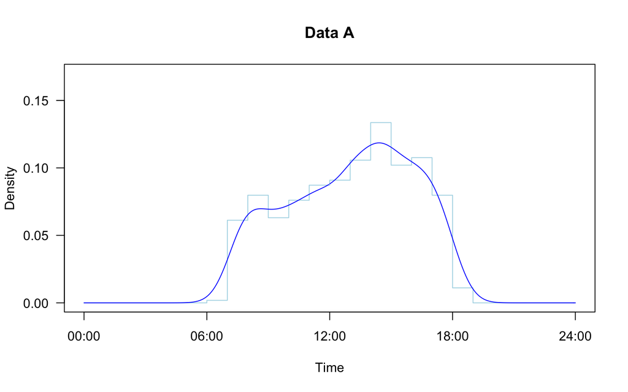

```r
#Density plot for dataset A
plot(fitact_a, yunit="dens", las=1, dline=list(col="lightblue"), tline=list(col="blue"), main="Data A", ylim=c(0,0.17))
```

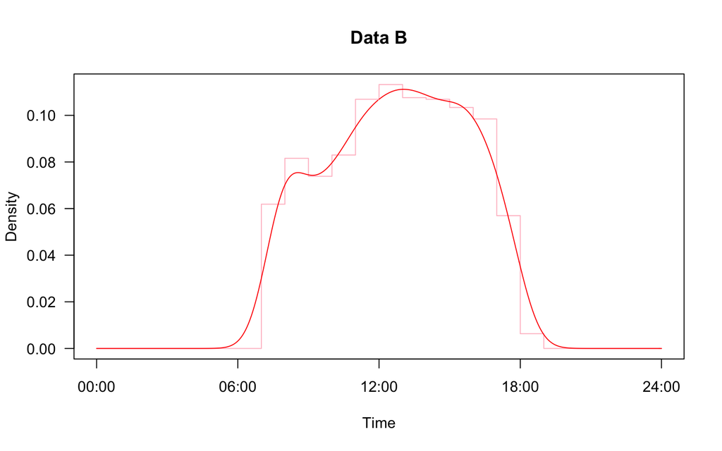

```r
#Density plot for dataset B
plot(fitact_b, yunit="dens", las=1, dline=list(col="pink"), tline=list(col="red"), main = "Data B")
```

And we also are able to depict both kernels in one plot:

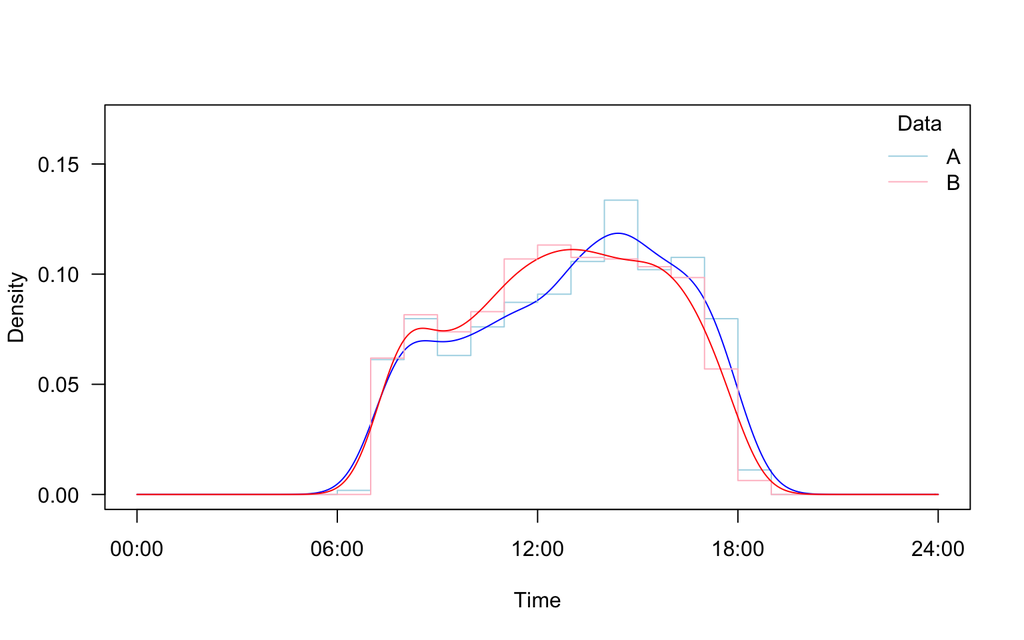

```r
plot(fitact_a, yunit="dens", las=1, dline=list(col="lightblue"), tline=list(col="blue"), ylim=c(0,0.17))
     plot(fitact_b, yunit="dens", add=TRUE, dline=list(col="pink"), tline=list(col="red"))
     legend("topright", inset = c(0,0), title = "Data", c("A", "B"), lty= c(1,1), col = c("lightblue", "pink"), bty = "n")
```

It is very nice, isn’t it?

## Overlap coefficient *dhat5*

The overlap coefficient of is the area under a density curve.This index is merely descriptive. On the other hand, the function `CompareCkern` of the package `activity`, is a probability test that assess if two datasets come from the same activity distribution. In addition, this test calculate overlap index *dhat5* for two fitted distributions (with function `fitact`).

Below we compare datasets X and Y, and test if they come or not from the same activity distribution:

```r
compareCkern(fitact_a, fitact_b, reps = 100)
```

```
##       obs      null    seNull     pNull
## 0.9452857 0.9600244 0.0125467 0.0900000
```

## Overlap assessment

Before plotting overlaps we must extracti data for condition = A…

```r
act_a <- rad_x[act_x$Condition=="A"]
act_b <- rad_y[act_y$Condition=="A"]
```

And now we will graph the Density Plots!

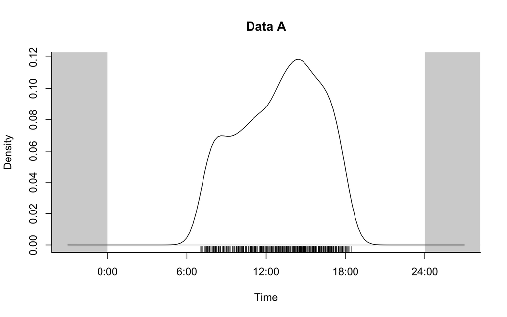

```r
#Density plot for A
densityPlot(act_a, xscale = 24, xcenter = c("noon", "midnight"), add = F, rug = T, extend = "lightgray", main = "Data A", xlab = "Time", ylab = "Density", bty = "L")
```

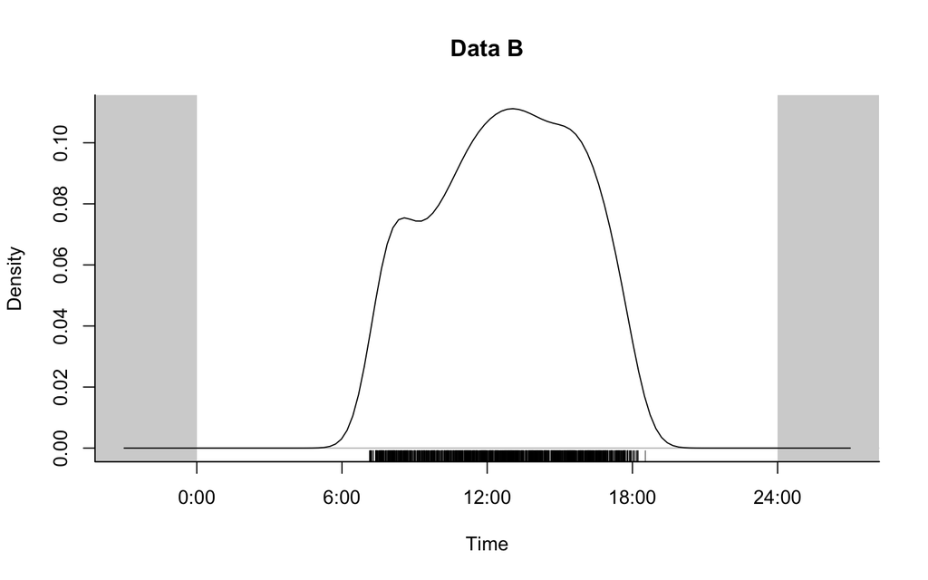

```r
#Density plot for B
densityPlot(act_b, xscale = 24, xcenter = c("noon", "midnight"), add = F, rug = T, extend = "lightgray", main = "Data B", xlab = "Time", ylab = "Density", bty = "L")
```

And of course, we can plot the two datasets in same plot with `overlap`

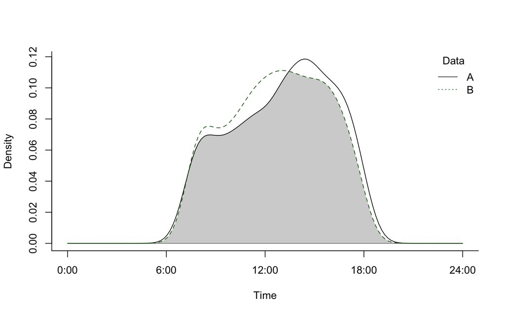

```r
overlapPlot(act_a, act_b, main = " ", linecol = c("black", "darkgreen"), lty = c(1,3), bty = "L", xlab = "Time", ylab = "Density")
legend("topright", inset = c(0,0), title = "Data", c("A", "B"), lty= c(1,3), col = c("gray25", "seagreen"), bty = "n")
```

Licensing Creative Commons License

Licensed under a Creative Commons Attribution-ShareAlike 4.0 International License.  
2019 - Francisco E. Fontúrbel